# **Problem Statement**

## Model 4: Transfer Learning with VGG-16 (Base + FFNN + Data Augmentation)

- In most of the real-world case studies, it is challenging to acquire a large number of images and then train CNNs.
- To overcome this problem, one approach we might consider is **Data Augmentation**.
- CNNs have the property of **translational invariance**, which means they can recognise an object even if its appearance shifts translationally in some way. - Taking this attribute into account, we can augment the images using the techniques listed below
  - Horizontal Flip (should be set to True/False)
  - Vertical Flip (should be set to True/False)
  - Height Shift (should be between 0 and 1)
  - Width Shift (should be between 0 and 1)
  - Rotation (should be between 0 and 180)
  - Shear (should be between 0 and 1)
  - Zoom (should be between 0 and 1) etc.

Remember, **data augmentation should not be used in the validation/test data set**.

```
Model: "sequential_4"
```

```
┏━━━━━━━━━━━━━━━━━━━━━━━━━━━━━━━━━┳━━━━━━━━━━━━━━━━━━━━━━━━┳━━━━━━━━━━━━━━━┓
┃ Layer (type)                    ┃ Output Shape           ┃       Param # ┃
┡━━━━━━━━━━━━━━━━━━━━━━━━━━━━━━━━━╇━━━━━━━━━━━━━━━━━━━━━━━━╇━━━━━━━━━━━━━━━┩
│ vgg16 (Functional)              │ (None, 6, 6, 512)      │    14,714,688 │
├─────────────────────────────────┼────────────────────────┼───────────────┤
│ flatten_4 (Flatten)             │ (None, 18432)          │             0 │
├─────────────────────────────────┼────────────────────────┼───────────────┤
│ dense_8 (Dense)                 │ (None, 512)            │     9,437,696 │
├─────────────────────────────────┼────────────────────────┼───────────────┤
│ dropout_3 (Dropout)             │ (None, 512)            │             0 │
├─────────────────────────────────┼────────────────────────┼───────────────┤
│ dense_9 (Dense)                 │ (None, 64)             │        32,832 │
├─────────────────────────────────┼────────────────────────┼───────────────┤
│ dense_10 (Dense)                │ (None, 1)              │            65 │
└─────────────────────────────────┴────────────────────────┴───────────────┘
```

```
 Total params: 24,185,281 (92.26 MB)
```

```
 Trainable params: 9,470,593 (36.13 MB)
```

```
 Non-trainable params: 14,714,688 (56.13 MB)
```

```
90/90 - 39s - 437ms/step - accuracy: 0.7552 - loss: 0.5664 - val_accuracy: 0.8207 - val_loss: 0.3553
90/90 - 3s - 34ms/step - accuracy: 0.7188 - loss: 0.6131 - val_accuracy: 0.8368 - val_loss: 0.3351
90/90 - 36s - 401ms/step - accuracy: 0.8077 - loss: 0.4063 - val_accuracy: 0.8191 - val_loss: 0.3613
90/90 - 3s - 33ms/step - accuracy: 0.7188 - loss: 0.4697 - val_accuracy: 0.8320 - val_loss: 0.3211
90/90 - 36s - 402ms/step - accuracy: 0.8336 - loss: 0.3595 - val_accuracy: 0.8627 - val_loss: 0.2913
90/90 - 3s - 33ms/step - accuracy: 0.8125 - loss: 0.3491 - val_accuracy: 0.8659 - val_loss: 0.2922
90/90 - 36s - 402ms/step - accuracy: 0.8358 - loss: 0.3597 - val_accuracy: 0.8578 - val_loss: 0.2955
90/90 - 2s - 27ms/step - accuracy: 0.7143 - loss: 0.5383 - val_accuracy: 0.8643 - val_loss: 0.2913
90/90 - 36s - 401ms/step - accuracy: 0.8424 - loss: 0.3537 - val_accuracy: 0.8514 - val_loss: 0.2879
90/90 - 3s - 30ms/step - accuracy: 0.8438 - loss: 0.3242 - val_accuracy: 0.8401 - val_loss: 0.3293
90/90 - 39s - 434ms/step - accuracy: 0.8543 - loss: 0.3268 - val_accuracy: 0.8595 - val_loss: 0.2958
90/90 - 3s - 30ms/step - accuracy: 0.8438 - loss: 0.3709 - val_accuracy: 0.8514 - val_loss: 0.3085
90/90 - 37s - 408ms/step - accuracy: 0.8518 - loss: 0.3242 - val_accuracy: 0.8772 - val_loss: 0.2745
90/90 - 3s - 30ms/step - accuracy: 0.8750 - loss: 0.2510 - val_accuracy: 0.8724 - val_loss: 0.2728
90/90 - 37s - 408ms/step - accuracy: 0.8557 - loss: 0.3144 - val_accuracy: 0.8611 - val_loss: 0.2904
90/90 - 3s - 30ms/step - accuracy: 0.9062 - loss: 0.2667 - val_accuracy: 0.8627 - val_loss: 0.2966
90/90 - 37s - 407ms/step - accuracy: 0.8609 - loss: 0.3080 - val_accuracy: 0.8691 - val_loss: 0.2840
90/90 - 3s - 30ms/step - accuracy: 0.8438 - loss: 0.3320 - val_accuracy: 0.8708 - val_loss: 0.2756
90/90 - 36s - 405ms/step - accuracy: 0.8609 - loss: 0.3107 - val_accuracy: 0.8724 - val_loss: 0.2721
90/90 - 3s - 31ms/step - accuracy: 0.9688 - loss: 0.1823 - val_accuracy: 0.8724 - val_loss: 0.2742
90/90 - 37s - 411ms/step - accuracy: 0.8715 - loss: 0.3007 - val_accuracy: 0.8530 - val_loss: 0.3198
90/90 - 3s - 34ms/step - accuracy: 0.8750 - loss: 0.3968 - val_accuracy: 0.8417 - val_loss: 0.3517
90/90 - 37s - 412ms/step - accuracy: 0.8715 - loss: 0.2919 - val_accuracy: 0.8869 - val_loss: 0.2537
90/90 - 3s - 33ms/step - accuracy: 0.8750 - loss: 0.3125 - val_accuracy: 0.8805 - val_loss: 0.2613
90/90 - 37s - 413ms/step - accuracy: 0.8673 - loss: 0.3139 - val_accuracy: 0.8708 - val_loss: 0.2806
90/90 - 3s - 31ms/step - accuracy: 0.9062 - loss: 0.2836 - val_accuracy: 0.8724 - val_loss: 0.2743
90/90 - 37s - 411ms/step - accuracy: 0.8599 - loss: 0.3074 - val_accuracy: 0.8918 - val_loss: 0.2523
90/90 - 3s - 30ms/step - accuracy: 0.7812 - loss: 0.4322 - val_accuracy: 0.8869 - val_loss: 0.2535
90/90 - 37s - 412ms/step - accuracy: 0.8634 - loss: 0.3006 - val_accuracy: 0.8821 - val_loss: 0.2610
90/90 - 3s - 30ms/step - accuracy: 0.9688 - loss: 0.1311 - val_accuracy: 0.8772 - val_loss: 0.2612
90/90 - 37s - 411ms/step - accuracy: 0.8788 - loss: 0.2832 - val_accuracy: 0.8627 - val_loss: 0.2718
90/90 - 3s - 30ms/step - accuracy: 0.8750 - loss: 0.2235 - val_accuracy: 0.8805 - val_loss: 0.2575
90/90 - 37s - 414ms/step - accuracy: 0.8715 - loss: 0.2787 - val_accuracy: 0.8498 - val_loss: 0.3035
90/90 - 3s - 30ms/step - accuracy: 0.8438 - loss: 0.3746 - val_accuracy: 0.8611 - val_loss: 0.2911
90/90 - 38s - 418ms/step - accuracy: 0.8613 - loss: 0.3042 - val_accuracy: 0.8869 - val_loss: 0.2807
90/90 - 3s - 30ms/step - accuracy: 0.8750 - loss: 0.2697 - val_accuracy: 0.8853 - val_loss: 0.2805
90/90 - 37s - 407ms/step - accuracy: 0.8718 - loss: 0.2841 - val_accuracy: 0.8837 - val_loss: 0.2661
90/90 - 3s - 30ms/step - accuracy: 0.9375 - loss: 0.1886 - val_accuracy: 0.8837 - val_loss: 0.2594
90/90 - 36s - 400ms/step - accuracy: 0.8809 - loss: 0.2767 - val_accuracy: 0.8821 - val_loss: 0.2624
90/90 - 3s - 30ms/step - accuracy: 0.9062 - loss: 0.2590 - val_accuracy: 0.8611 - val_loss: 0.2730
90/90 - 36s - 397ms/step - accuracy: 0.8694 - loss: 0.2937 - val_accuracy: 0.8869 - val_loss: 0.2575
90/90 - 3s - 32ms/step - accuracy: 0.8125 - loss: 0.3497 - val_accuracy: 0.8740 - val_loss: 0.2804
90/90 - 35s - 394ms/step - accuracy: 0.8676 - loss: 0.2996 - val_accuracy: 0.8837 - val_loss: 0.2691
90/90 - 3s - 33ms/step - accuracy: 0.8750 - loss: 0.3452 - val_accuracy: 0.8805 - val_loss: 0.2765
90/90 - 35s - 393ms/step - accuracy: 0.8701 - loss: 0.2847 - val_accuracy: 0.8805 - val_loss: 0.2677
90/90 - 3s - 32ms/step - accuracy: 0.8750 - loss: 0.2357 - val_accuracy: 0.8772 - val_loss: 0.2709
90/90 - 35s - 394ms/step - accuracy: 0.8732 - loss: 0.2768 - val_accuracy: 0.8837 - val_loss: 0.2625
90/90 - 3s - 33ms/step - accuracy: 0.8125 - loss: 0.2828 - val_accuracy: 0.8675 - val_loss: 0.2676
90/90 - 36s - 399ms/step - accuracy: 0.8799 - loss: 0.2714 - val_accuracy: 0.8546 - val_loss: 0.3178
90/90 - 3s - 32ms/step - accuracy: 0.9062 - loss: 0.3320 - val_accuracy: 0.8530 - val_loss: 0.3231
```

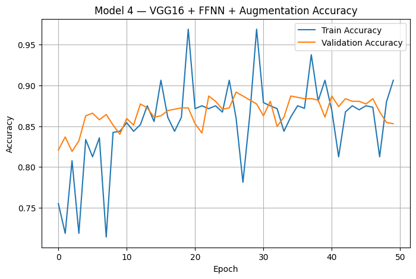

```
Training Performance:
91/91 ━━━━━━━━━━━━━━━━━━━━ 12s 118ms/step
   Accuracy    Recall  Precision  F1 Score
0  0.892622  0.892622   0.892622  0.892622
91/91 ━━━━━━━━━━━━━━━━━━━━ 12s 118ms/step
```

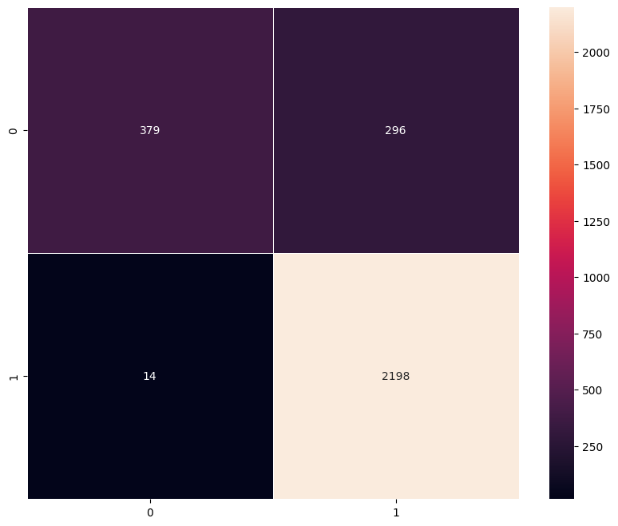

```
Validation Performance:
20/20 ━━━━━━━━━━━━━━━━━━━━ 3s 119ms/step
   Accuracy    Recall  Precision  F1 Score
0  0.852989  0.852989   0.852989  0.852989
20/20 ━━━━━━━━━━━━━━━━━━━━ 3s 120ms/step
```

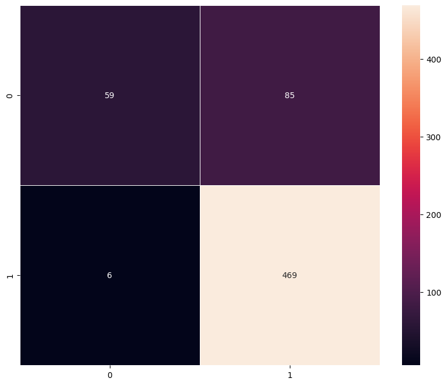

```python
# ---------------------------------------------------------
# Model 4: VGG-16 (Base + FFNN + Data Augmentation)
# ---------------------------------------------------------

from tensorflow.keras.applications import VGG16
from tensorflow.keras.models import Sequential
from tensorflow.keras.layers import Flatten, Dense, Dropout
from tensorflow.keras.optimizers import Adam
from tensorflow.keras.preprocessing.image import ImageDataGenerator
import matplotlib.pyplot as plt

# Load VGG16 base model
vgg16_base = VGG16(
    weights='imagenet',
    include_top=False,
    input_shape=X_train_normalized.shape[1:]
)

# Freeze convolutional layers
for layer in vgg16_base.layers:
    layer.trainable = False

# Build Model 4
model_4 = Sequential()
model_4.add(vgg16_base)
model_4.add(Flatten())

# Feed-forward layers
model_4.add(Dense(512, activation='relu'))
model_4.add(Dropout(0.3))
model_4.add(Dense(64, activation='relu'))
model_4.add(Dense(1, activation='sigmoid'))

# Compile model
opt = Adam(learning_rate=0.001)
model_4.compile(
    optimizer=opt,
    loss='binary_crossentropy',
    metrics=['accuracy']
)

model_4.summary()

# ---------------------------------------------------------
# Data Augmentation
# ---------------------------------------------------------

datagen = ImageDataGenerator(
    rotation_range=20,
    width_shift_range=0.2,
    height_shift_range=0.2,
    shear_range=0.2,
    zoom_range=0.2,
    horizontal_flip=True,
    fill_mode='nearest'
)

batch_size = 32
epochs = 50

history_4 = model_4.fit(
    datagen.flow(X_train_normalized, y_train, batch_size=batch_size),
    epochs=epochs,
    steps_per_epoch=len(X_train_normalized) // batch_size,
    validation_data=(X_val_normalized, y_val),
    verbose=2
)

# ---------------------------------------------------------
# Plot Training Curves
# ---------------------------------------------------------

plt.figure(figsize=(8,5))
plt.plot(history_4.history['accuracy'], label='Train Accuracy')
plt.plot(history_4.history['val_accuracy'], label='Validation Accuracy')
plt.title('Model 4 — VGG16 + FFNN + Augmentation Accuracy')
plt.xlabel('Epoch')
plt.ylabel('Accuracy')
plt.legend()
plt.grid(True)
plt.show()

# ---------------------------------------------------------
# Evaluate Model
# ---------------------------------------------------------

print("Training Performance:")
model_4_train_perf = model_performance_classification(model_4, X_train_normalized, y_train)
print(model_4_train_perf)
plot_confusion_matrix(model_4, X_train_normalized, y_train)

print("\nValidation Performance:")
model_4_valid_perf = model_performance_classification(model_4, X_val_normalized, y_val)
print(model_4_valid_perf)
plot_confusion_matrix(model_4, X_val_normalized, y_val)
```